# Project 1

```r
library(car)
```

# All models

Load data

```r
bodyF <- read.csv("./bodyfatmen.csv",
               header = TRUE)
View(bodyF)
n <- nrow(bodyF)
p <- ncol(bodyF) # k+1
```

Create full model

```r
bodyF.model <- lm(density ~ ., data = bodyF)
summary(bodyF.model)
```

```
Call:
lm(formula = density ~ ., data = bodyF)

Residuals:
       Min         1Q     Median         3Q        Max
-0.0225107 -0.0071735  0.0002816  0.0064878  0.0254670

Coefficients:
              Estimate Std. Error t value Pr(>|t|)
(Intercept)  1.156e+00  5.061e-02  22.846  < 2e-16 ***
age         -1.320e-04  7.392e-05  -1.785  0.07550 .
weight       2.378e-04  1.408e-04   1.689  0.09254 .
height      -2.594e-05  4.083e-04  -0.064  0.94939
neck         1.072e-03  5.371e-04   1.995  0.04720 *
chest        1.169e-05  2.360e-04   0.050  0.96056
abdomen     -2.200e-03  2.072e-04 -10.618  < 2e-16 ***
hip          5.268e-04  3.336e-04   1.579  0.11569
thigh       -6.343e-04  3.336e-04  -1.901  0.05849 .
knee        -3.418e-05  5.640e-04  -0.061  0.95172
ankle       -4.449e-04  5.107e-04  -0.871  0.38459
biceps      -4.274e-04  3.942e-04  -1.084  0.27940
forearm     -1.040e-03  4.527e-04  -2.298  0.02245 *
wrist        3.651e-03  1.227e-03   2.976  0.00322 **
---
Signif. codes:  0 ‘***’ 0.001 ‘**’ 0.01 ‘*’ 0.05 ‘.’ 0.1 ‘ ’ 1

Residual standard error: 0.009781 on 234 degrees of freedom
Multiple R-squared:  0.7451,    Adjusted R-squared:  0.731
F-statistic: 52.63 on 13 and 234 DF,  p-value: < 2.2e-16
```

We see that the model have a lot of confidence with abdomen and wrist but no so much with height, chest, hip, knee, ankle and biceps

## Residuals analysis

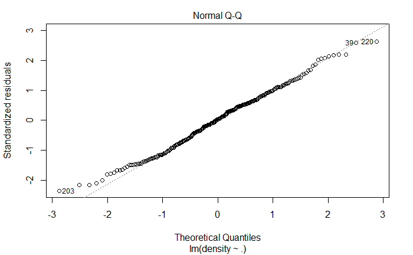

```r
# Normal probability plot of residuals
plot(bodyF.model, which=2)
```

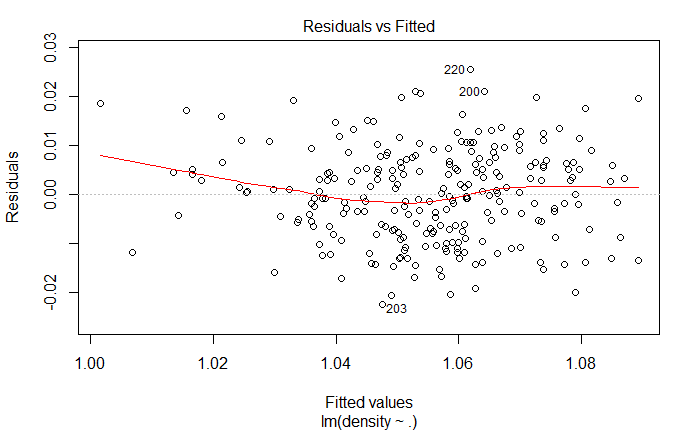

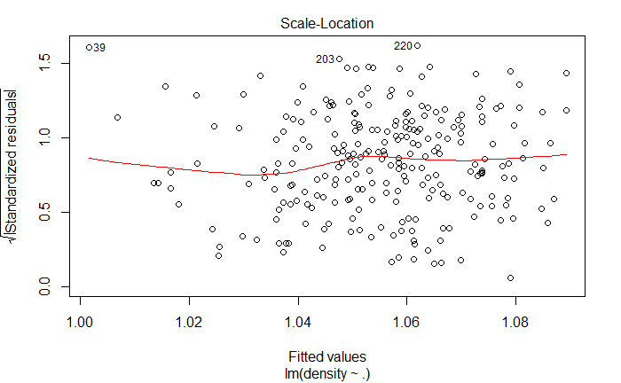

```r
# Residuals vs. fitted values
plot(bodyF.model, which=c(1,3))
```

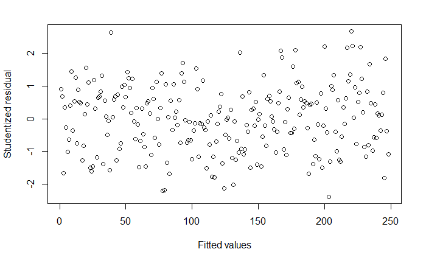

```r
plot(studres(bodyF.model), xlab="Fitted values", ylab="Studentized residual")
```

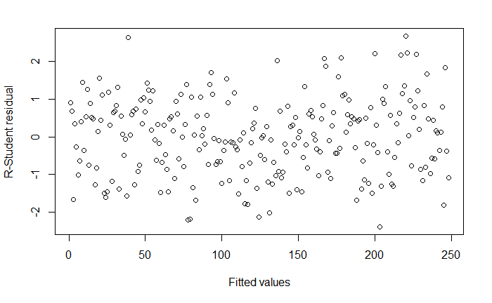

```r
plot(rstudent(bodyF.model), xlab="Fitted values", ylab="R-Student residual")
```

Semms very good, we do not see any aparent shape, which corresponds to a uncorrelated fitted values with the residuals. We can see in the standarized residuals vs fitted values, that the points 39, 203, and 220 have a standarized residual higher than the variance, which could indicate us that they are outliers. Funnel?

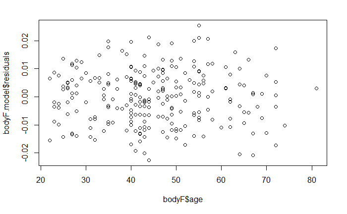

```r
### Horizontal band, so satisfactory distribution
#par(mfrow = c(3, 3))
# Residuals vs. regressor variables
plot(bodyF$age, bodyF.model$residuals)
```

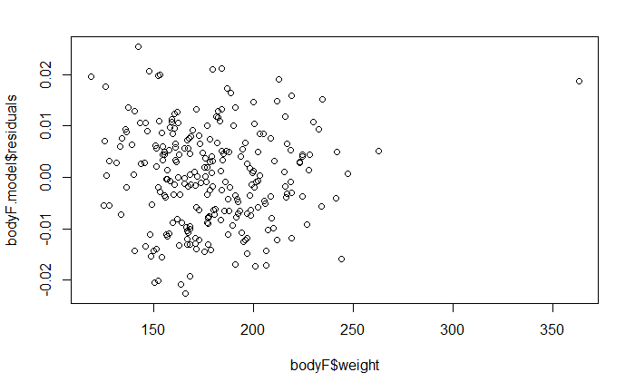

```r
plot(bodyF$weight, bodyF.model$residuals)
```

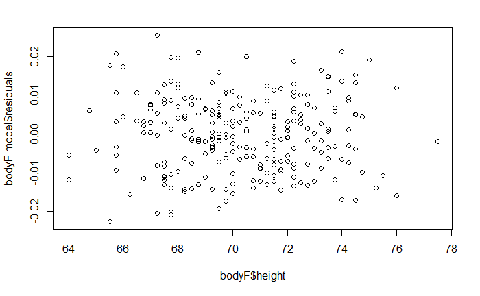

```r
plot(bodyF$height, bodyF.model$residuals)
```

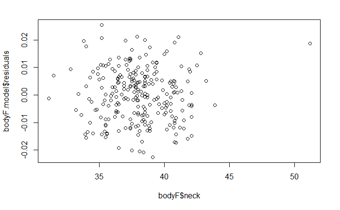

```r
plot(bodyF$neck, bodyF.model$residuals)
```

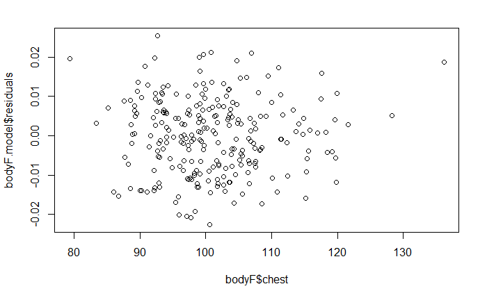

```r
plot(bodyF$chest, bodyF.model$residuals)
```

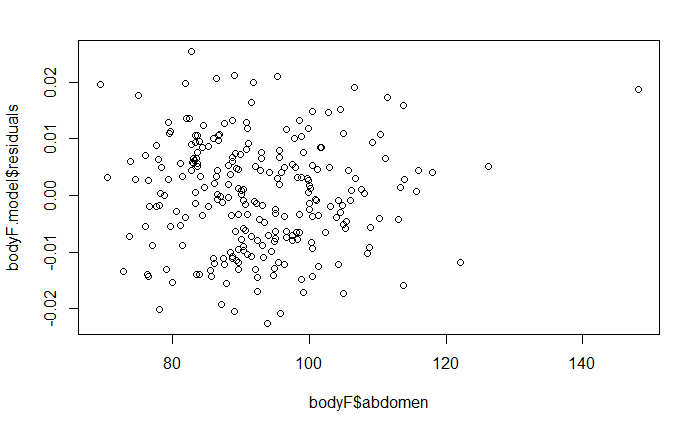

```r
plot(bodyF$abdomen, bodyF.model$residuals)
```

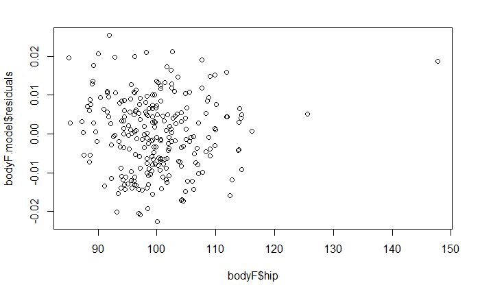

```r
plot(bodyF$hip, bodyF.model$residuals)
```

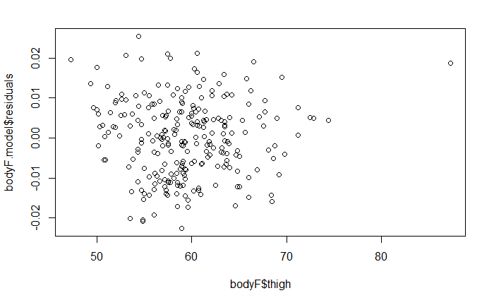

```r
plot(bodyF$thigh, bodyF.model$residuals)
```

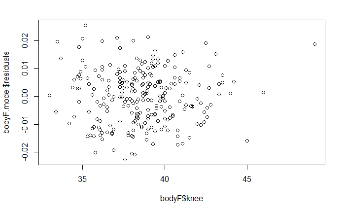

```r
plot(bodyF$knee, bodyF.model$residuals)
```

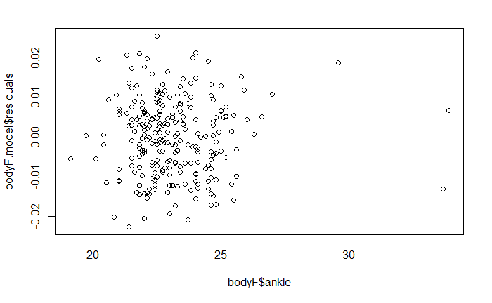

```r
plot(bodyF$ankle, bodyF.model$residuals)
```

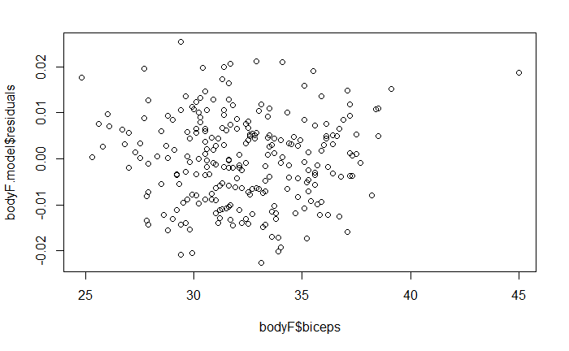

```r
plot(bodyF$biceps, bodyF.model$residuals)
```

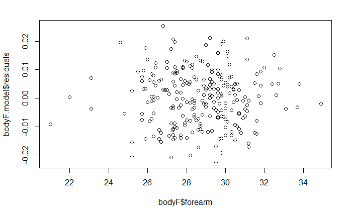

```r
plot(bodyF$forearm, bodyF.model$residuals)
```

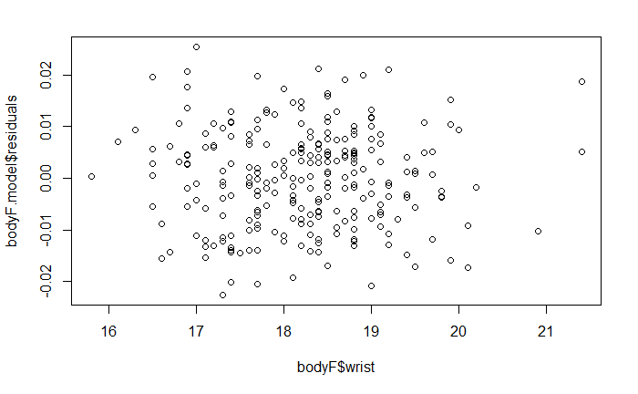

```r
plot(bodyF$wrist, bodyF.model$residuals)
```

We see that all the plots have a rectangular shape, indicating that the uncorrelation between the regresors and the residuals.

```r
# Partial residual plots
avPlots(bodyF.model)
```

[output not shown]

```r
# PRESS statistics
pr <- resid(bodyF.model)/(1 - lm.influence(bodyF.model)$hat)
PRESS <- sum(pr^2)
SSt <- sum((bodyF$density - mean(bodyF$density))^2)
R2prediction <- 1 - PRESS/SSt
print(R2prediction)
```

```
[1] 0.7052601
```

We could expect this model to explain about 70.52% of the variabilityin predicting new observations. Which is not as desirable, but it is not that much of a trade off compared to the R2 0.7451.

## Leverage and outliers

```r
# Define cutoff
leverage.cutoff <- 2 * p / n  # MPV p. 213
cooks.cutoff <- qf(0.5, p, n - p, lower.tail = FALSE)  # MPV p. 215
dfbetas.cutoff <- 2 / sqrt(n)  # MPV p. 218
dffits.cutoff <- 2 * sqrt(p / n)  # MPV p. 219
studres.cutoff <- qt(0.05 / 2, n - p, lower.tail = FALSE)  # MPV p. 135
```

```r
### leverage points
bodyF.hat <- hatvalues(bodyF.model)
a <-bodyF.hat[bodyF.hat > leverage.cutoff]
print(a)
```

```
        5        31        36        39        41        52        83       102       155       171       202       212
0.1221526 0.3266160 0.2006317 0.4580794 0.2170594 0.1694985 0.3631388 0.1817106 0.1879068 0.2729657 0.1836120 0.1312186
```

```r
View(bodyF[names(a),])
```

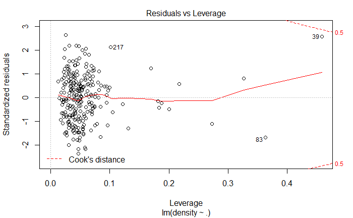

```r
plot(bodyF.model, which=5)
```

We can see that none of the points are considered as influentials based on the Cooks distance cutoff. However, we have the points 39 and 83 which are high leverage points and are the closest to being influential. Analizing the data we observe that the point 39 corresponts to the heaviest individual (having a 100 pound gap), so that translates to having high leverage. Moreover, as we saw in the stundentized vs fitted plot it had one of the highest residual (no so good of a fit), so that made high more influential than the rest.

```r
### Cook's distance
bodyF.cooks <- cooks.distance(bodyF.model)
bodyF.cooks[bodyF.cooks > cooks.cutoff]
```

```
named numeric(0)
```

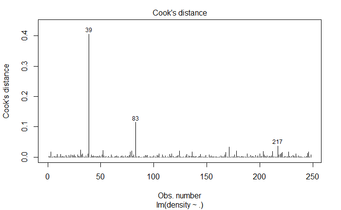

```r
plot(bodyF.model, which=4)
```

This plot confirms our findings of not having a influential point based on Cooks distance, however we see that the point 39 has a much high value compared to the rest.

```r
influence.measures(bodyF.model)
```

```
Influence measures of
     lm(formula = density ~ ., data = bodyF) :
```

[output not shown]

[output cut: 238 more lines]

```r
### DFBETAS
bodyF.dfbetas <- dfbetas(bodyF.model)
bodyF.model.extra <- bodyF.model
bodyF.model.extra$dfbetas0 <-bodyF.dfbetas[, 1]
bodyF.model.extra$dfbetas1 <-bodyF.dfbetas[, 2]
bodyF.model.extra$dfbetas2 <-bodyF.dfbetas[, 3]
bodyF.model.extra$dfbetas3 <-bodyF.dfbetas[, 4]
bodyF.model.extra$dfbetas4 <-bodyF.dfbetas[, 5]
bodyF.model.extra$dfbetas5 <-bodyF.dfbetas[, 6]
bodyF.model.extra$dfbetas6 <-bodyF.dfbetas[, 7]
bodyF.model.extra$dfbetas7 <-bodyF.dfbetas[, 8]
bodyF.model.extra$dfbetas8 <-bodyF.dfbetas[, 9]
bodyF.model.extra$dfbetas9 <-bodyF.dfbetas[, 10]
bodyF.model.extra$dfbetas10 <-bodyF.dfbetas[, 11]
bodyF.model.extra$dfbetas11 <-bodyF.dfbetas[, 12]
bodyF.model.extra$dfbetas12 <-bodyF.dfbetas[, 13]
```

```r
print("beta_0")
```

```
[1] "beta_0"
```

```r
bodyF.dfbetas[abs(bodyF.dfbetas[, 1]) > dfbetas.cutoff, 1]  # beta_0
```

```
        28         31         32         39         52         79        105        108        136        167        178
 0.1275005 -0.1645811 -0.1622133  0.9622560 -0.1278719  0.2204529  0.1987150 -0.1491671 -0.1738196  0.1710348  0.2984035
       200        217        227
-0.2474151 -0.6143066  0.2186483
```

```r
print("beta_1")
```

```
[1] "beta_1"
```

```r
bodyF.dfbetas[abs(bodyF.dfbetas[, 2]) > dfbetas.cutoff, 2]  # beta_1
```

```
         3         22         28         32         39         60         65         73         83        167        168
 0.2264141 -0.1755531  0.1532103 -0.1334348  0.2993823 -0.1489553 -0.1314085  0.1582091 -0.3216466 -0.1527851 -0.1514212
       171        200        220
 0.1907641  0.1509759  0.2398975
```

```r
print("beta_2")
```

```
[1] "beta_2"
```

```r
bodyF.dfbetas[abs(bodyF.dfbetas[, 3]) > dfbetas.cutoff, 3]  # beta_2
```

```
        28         31         32         33         39         52         77         79        105        108        136
 0.1910872 -0.1596849 -0.1804867 -0.1335697  1.1848457 -0.1369898 -0.1303200  0.2819799  0.1320421 -0.1998262 -0.1298476
       178        200        203        217        227
 0.2259037 -0.1637356  0.1367985 -0.6437765  0.1362152
```

```r
print("beta_3")
```

```
[1] "beta_3"
```

```r
bodyF.dfbetas[abs(bodyF.dfbetas[, 4]) > dfbetas.cutoff, 4]  # beta_3
```

```
        25         31         39         52        105        108        124        136        152        167        168
 0.1306294  0.1287812 -1.0907452  0.1715735 -0.1687164  0.1562086  0.1415700  0.2518155 -0.1342651 -0.1869385 -0.1803941
       178        200        203        212        217        219        227        236
-0.1835731  0.2621200  0.1468897  0.1385585  0.4386623 -0.1593060 -0.1298247  0.1313992
```

```r
print("beta_4")
```

```
[1] "beta_4"
```

```r
bodyF.dfbetas[abs(bodyF.dfbetas[, 5]) > dfbetas.cutoff, 5]  # beta_4
```

```
        25         28         38         39         60         70         79        135        136        203        217
 0.1387171 -0.2261259 -0.1874692  0.3179368  0.2502400  0.1301147 -0.2957687  0.1334902  0.1296067 -0.2562471  0.2266934
       221        227        231
 0.1763370 -0.1536460 -0.1760375
```

```r
print("beta_5")
```

```
[1] "beta_5"
```

```r
bodyF.dfbetas[abs(bodyF.dfbetas[, 6]) > dfbetas.cutoff, 6]  # beta_5
```

```
        24         39         78        105        115        117        136        144        171        178        200
 0.1808341 -0.9303603  0.1569124 -0.2711852  0.1651691  0.1427623 -0.1571710 -0.1474978 -0.1811290 -0.2974786  0.1581427
       204        217
 0.1335592  0.2286385
```

```r
print("beta_6")
```

```
[1] "beta_6"
```

```r
bodyF.dfbetas[abs(bodyF.dfbetas[, 7]) > dfbetas.cutoff, 7]  # beta_6
```

```
         9         12         25         39         78        103        105        108        116        124        136
-0.2016570 -0.1389440  0.1466810 -0.5832301 -0.1985854  0.1332147  0.1497342  0.1747529  0.1520229  0.2783675  0.2548353
       188        200        204        212        217        246
-0.1322730 -0.1313082 -0.1888010 -0.1538701  0.3016702  0.1851372
```

```r
print("beta_7")
```

```
[1] "beta_7"
```

```r
bodyF.dfbetas[abs(bodyF.dfbetas[, 8]) > dfbetas.cutoff, 8]  # beta_7
```

```
        32         36         39         57         79        105        131        188        196        198        200
 0.1918527 -0.1681967  0.3081569  0.1445822 -0.2636870 -0.1391965 -0.1372708  0.1297061  0.1572457 -0.1294314  0.2145154
       203        217        218        227        234
-0.1825293  0.2123914 -0.1449893 -0.1712370  0.1443337
```

```r
print("beta_8")
```

```
[1] "beta_8"
```

```r
bodyF.dfbetas[abs(bodyF.dfbetas[, 9]) > dfbetas.cutoff, 9]  # beta_8
```

```
        38         39         51         52         94        117        124        131        144        178        203
-0.1274267 -0.4364876 -0.1334722 -0.1288365  0.1631073  0.1605168  0.1876068  0.1726069 -0.1636021 -0.2406378  0.1334308
       212        217        246
 0.1633363  0.1590376  0.1300282
```

```r
print("beta_9")
```

```
[1] "beta_9"
```

```r
bodyF.dfbetas[abs(bodyF.dfbetas[, 10]) > dfbetas.cutoff, 10]  # beta_9
```

```
         3         12         33         39         41         79         81         83        163        188        212
-0.2135928 -0.1945099  0.1380090 -0.2075508 -0.1781601 -0.1797202  0.1613301  0.1970154  0.1353816 -0.1601653  0.2013550
       219        220        246
 0.1772035 -0.1692453 -0.1454113
```

```r
print("beta_10")
```

```
[1] "beta_10"
```

```r
bodyF.dfbetas[abs(bodyF.dfbetas[, 11]) > dfbetas.cutoff, 11]  # beta_10
```

```
         3         31         83        124        217        218        220
-0.1336465  0.5471185 -1.2011478  0.1327091  0.2250557  0.1284234  0.1747560
```

```r
print("beta_11")
```

```
[1] "beta_11"
```

```r
bodyF.dfbetas[abs(bodyF.dfbetas[, 12]) > dfbetas.cutoff, 12]  # beta_11
```

```
        20         33         38         52         83        100        103        124        131        144        168
 0.1446966  0.2027172  0.1413659  0.4896966 -0.1791366  0.1355381 -0.1436447 -0.2615580 -0.1909455  0.1394613 -0.2159668
       204        211        219        227
-0.1542751  0.1296142 -0.1872418  0.1510100
```

```r
print("beta_12")
```

```
[1] "beta_12"
```

```r
bodyF.dfbetas[abs(bodyF.dfbetas[, 13]) > dfbetas.cutoff, 13]  # beta_12
```

```
         3         39         52         79        171        202        217        245
 0.1345795 -0.8464080 -0.1716040  0.2148962  0.6042422  0.1763998  0.1270901  0.1302107
```

```r
pp <- ggplot(bodyF.model.extra, aes(x=fitted.values, y=dfbetas0)) +
    geom_line(data=bodyF.model.extra, aes(x=fitted.values, y=dfbetas.cutoff),col="#C79EC6") +geom_line(data=bodyF.model.extra, aes(x=fitted.values, y=-dfbetas.cutoff),col="#C79EC6")
ggplotly(pp, tooltip="text")
```

[output not shown]